# act_report

## Act Report

```
By Sodeinde Kehinde
```

## The dataset studied

Dogs ratings tweets from the famous twitter account WeRateDogs.

## Analysis

In this analysis I tried to find correlations between people's favorite dogs and their corresponding number of retweets, I was also able to life stages in dogs and their degree of popularity.

1- Life stages : I found that among those who gave information about their dogs stages the most frequent ones were puppers as it is shown in the bar graph below :

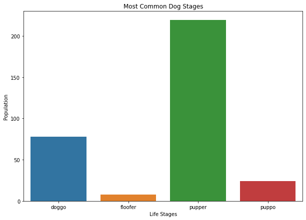

It's a bit tricky to come to conclusion that pupper are the most common or popular life stage in dogs as the dataset has lots of null values

1. To confirm relationship between the number of favorite dogs and their corresponding number of retweets, I used the scatter plot to show this.

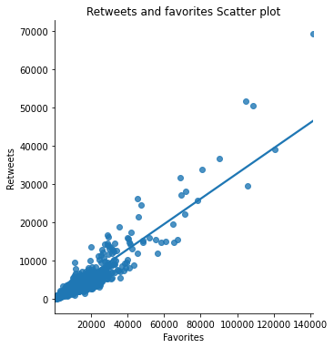

According to the scatter plot above, it is clear there is a strong association beween people's favorite dogs and their corresponding number of retweets.

1. To further clarify the above claim, I looked at the correlation coefficient stastically using the heatmap

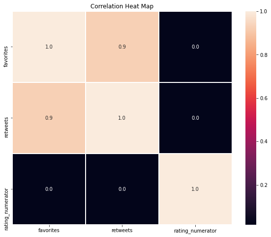

.

When exploring the most retweets posts a large portion of them were also found as favorite tweets.

These are some of the pictures I found to be fascinating and cute

[figure not shown]

[figure not shown]

[figure not shown]